# DATA 621 Homework #3

```r
library(tidyverse)
library(kableExtra)
library(visdat)
library(DT)
library(psych)
library(corrplot)
library(MASS)
library(matrixStats)
library(pacman)
p_load(Hmisc, xlsx, xtable, knitr, scales, magrittr, tidyverse, stringr, e1071, corrplot, knitcitations, bibtex, missForest, abc,
       foreach, doParallel, stargazer, forecast, matrixStats, glmulti, leaps, data.table, highlight, car, Amelia, caret)
```

# Overview

In this homework assignment, you will explore, analyze and model a data set containing information on crime for various neighborhoods of a major city. Each record has a response variable indicating whether or not the crime rate is above the median crime rate (1) or not (0).

Your objective is to build a binary logistic regression model on the training data set to predict whether the neighborhood will be at risk for high crime levels. You will provide classifications and probabilities for the evaluation data set using your binary logistic regression model. You can only use the variables given to you (or variables that you derive from the variables provided). Below is a short description of the variables of interest in the data set:

| Variable Name | Definition | Variable Type |
| --- | --- | --- |
| zn | proportion of residential land zoned for large lots (over 25000 square feet) | predictor |
| indus | proportion of non-retail business acres per suburb | predictor |
| chas | a dummy var. for whether the suburb borders the Charles River (1) or not (0) | predictor |
| nox | nitrogen oxides concentration (parts per 10 million) | predictor |
| rm | average number of rooms per dwelling | predictor |
| age | proportion of owner-occupied units built prior to 1940 | predictor |
| dis | weighted mean of distances to five Boston employment centers | predictor |
| rad | index of accessibility to radial highways | predictor |
| tax | full-value property-tax rate per $10,000 | predictor |
| ptratio | pupil-teacher ratio by town | predictor |
| black | 1000(Bk - 0.63)2 where Bk is the proportion of blacks by town | predictor |
| lstat | lower status of the population (percent) | predictor |
| medv | median value of owner-occupied homes in $1000s | predictor |
| target | whether the crime rate is above the median crime rate (1) or not (0) | response |

# Deliverables

A write-up of your solutions submitted in PDF format. Assigned prediction (probabilities, classifications) for the evaluation data set. Use 0.5 threshold.

# Data Exploration

```r
data_t <- read_csv("https://raw.githubusercontent.com/Rajwantmishra/DATA621_CR4/master/HW3/crime-training-data_modified.csv") %>%
  dplyr::select(target, everything())

data_e <- read_csv('https://raw.githubusercontent.com/Rajwantmishra/DATA621_CR4/master/HW3/crime-evaluation-data_modified.csv')
```

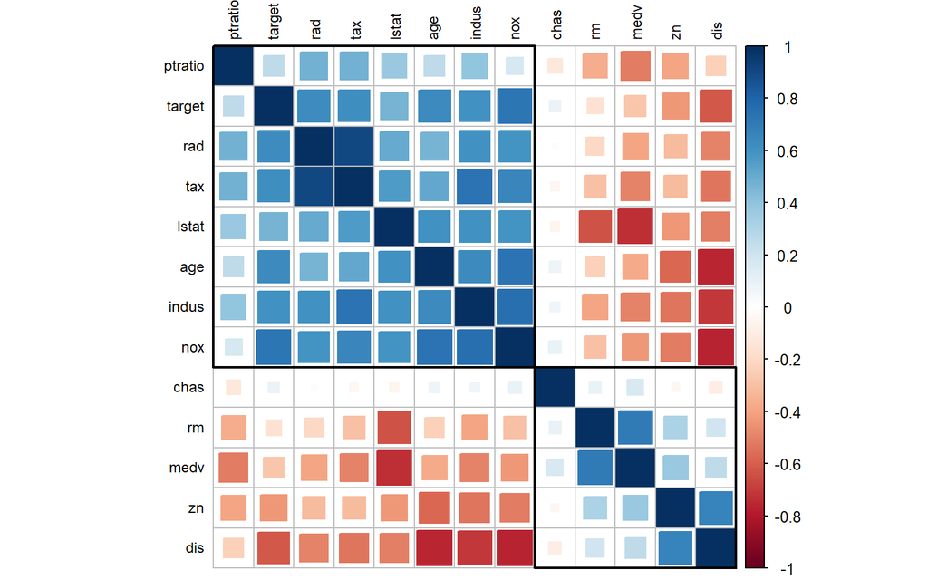

Correlation Plot of Training Data Set

We implement a correlation matrix to better understand the correlation between variables in the data set. The below matrix is the results and we noticed a few interesting correlations.

- `nox` : High nitrogen oxides concentration (parts per 10 million) (“nox”) is positively correlated with higher than median crime rates. As defined by the EPA - “NOx pollution is emitted by automobiles, trucks and various non-road vehicles (e.g., construction equipment, boats, etc.) as well as industrial sources such as power plants, industrial boilers, cement kilns, and turbines”. It is clear to see that nox is concentrated in areas of high road traffic and possible high industrial use which would be neighborhoods of low value and may attract crime.
- `dis`: The weighted mean of distances is negatively correlated with a city with higher than median crime rate. This is intuitive in that employment centers would be more closely located in cities of high crime due to high unemployment being positively correlated with higher crimes rates.
- `tax` : It is also counterintuitive how the crime rate has a positive correlation with the property tax. It would be anticipated that if the property tax increases, the crime rate would decrease due to the money that home occupants and owners would spend on “promised” security systems. However, when the crime rate starts to increase, the housing prices would decrease due to the fact that the home occupants and owners would not want to risk their safety.

## Missing Values & Data Type Check

Two data sets are given. One is the `training set`, which includes 12 candidate predictors, 1 response variable, and 466 observations without missing values (eg: NA, NULL or ’’). The other one is the `evaluation set`, which includes 12 candidate predictors only, 40 observations without missing values. However, the variable `black`, which is described in the overview section, is not presented in the data set.

Among the 12 candidate predictors, 1 is categorical (`chas`), the other 11 are continuous numerical. The response variable `target` is categorical.

```r
glimpse(data_t)
```

```
## Observations: 466
## Variables: 13
## $ target  <dbl> 1, 1, 1, 0, 0, 0, 1, 1, 0, 0, 0, 0, 1, 1, 0, 0, 0, 1, 1, 1,...
## $ zn      <dbl> 0, 0, 0, 30, 0, 0, 0, 0, 0, 80, 22, 0, 0, 22, 0, 0, 100, 20...
## $ indus   <dbl> 19.58, 19.58, 18.10, 4.93, 2.46, 8.56, 18.10, 18.10, 5.19, ...
## $ chas    <dbl> 0, 1, 0, 0, 0, 0, 0, 0, 0, 0, 0, 0, 0, 0, 0, 0, 0, 0, 0, 0,...
## $ nox     <dbl> 0.605, 0.871, 0.740, 0.428, 0.488, 0.520, 0.693, 0.693, 0.5...
## $ rm      <dbl> 7.929, 5.403, 6.485, 6.393, 7.155, 6.781, 5.453, 4.519, 6.3...
## $ age     <dbl> 96.2, 100.0, 100.0, 7.8, 92.2, 71.3, 100.0, 100.0, 38.1, 19...
## $ dis     <dbl> 2.0459, 1.3216, 1.9784, 7.0355, 2.7006, 2.8561, 1.4896, 1.6...
## $ rad     <dbl> 5, 5, 24, 6, 3, 5, 24, 24, 5, 1, 7, 5, 24, 7, 3, 3, 5, 5, 2...
## $ tax     <dbl> 403, 403, 666, 300, 193, 384, 666, 666, 224, 315, 330, 398,...
## $ ptratio <dbl> 14.7, 14.7, 20.2, 16.6, 17.8, 20.9, 20.2, 20.2, 20.2, 16.4,...
## $ lstat   <dbl> 3.70, 26.82, 18.85, 5.19, 4.82, 7.67, 30.59, 36.98, 5.68, 9...
## $ medv    <dbl> 50.0, 13.4, 15.4, 23.7, 37.9, 26.5, 5.0, 7.0, 22.2, 20.9, 2...
```

Table 1: Glimpse of `training set`

```r
glimpse(data_e)
```

```
## Observations: 40
## Variables: 12
## $ zn      <dbl> 0, 0, 0, 0, 0, 25, 25, 0, 0, 0, 0, 0, 0, 0, 0, 0, 0, 0, 22,...
## $ indus   <dbl> 7.07, 8.14, 8.14, 8.14, 5.96, 5.13, 5.13, 4.49, 4.49, 2.89,...
## $ chas    <dbl> 0, 0, 0, 0, 0, 0, 0, 0, 0, 0, 0, 0, 0, 0, 0, 1, 0, 0, 0, 0,...
## $ nox     <dbl> 0.469, 0.538, 0.538, 0.538, 0.499, 0.453, 0.453, 0.449, 0.4...
## $ rm      <dbl> 7.185, 6.096, 6.495, 5.950, 5.850, 5.741, 5.966, 6.630, 6.1...
## $ age     <dbl> 61.1, 84.5, 94.4, 82.0, 41.5, 66.2, 93.4, 56.1, 56.8, 69.6,...
## $ dis     <dbl> 4.9671, 4.4619, 4.4547, 3.9900, 3.9342, 7.2254, 6.8185, 4.4...
## $ rad     <dbl> 2, 4, 4, 4, 5, 8, 8, 3, 3, 2, 2, 2, 4, 5, 5, 4, 8, 8, 7, 1,...
## $ tax     <dbl> 242, 307, 307, 307, 279, 284, 284, 247, 247, 276, 188, 188,...
## $ ptratio <dbl> 17.8, 21.0, 21.0, 21.0, 19.2, 19.7, 19.7, 18.5, 18.5, 18.0,...
## $ lstat   <dbl> 4.03, 10.26, 12.80, 27.71, 8.77, 13.15, 14.44, 6.53, 8.44, ...
## $ medv    <dbl> 34.7, 18.2, 18.4, 13.2, 21.0, 18.7, 16.0, 26.6, 22.2, 21.4,...
```

Table 2: Glimpse of `evaluation set`

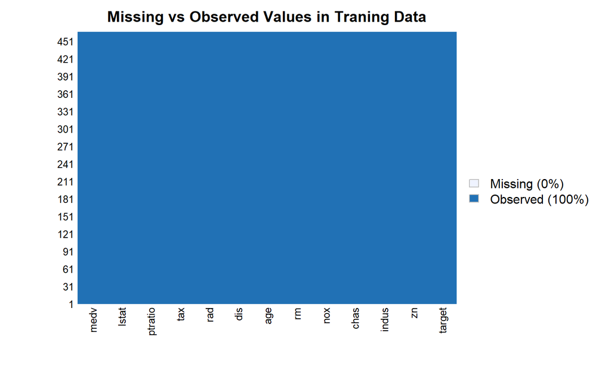

```r
Amelia::missmap(data_t, main = "Missing vs Observed Values in Traning Data")
```

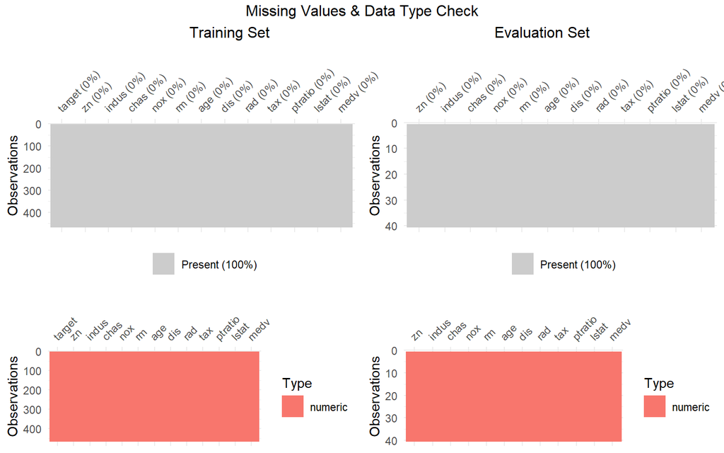

```r
library(gridExtra)
p_t_dt <- vis_dat(data_t)
p_t_m <- vis_miss(data_t)
p_e_dt <- vis_dat(data_e)
p_e_m <- vis_miss(data_e)
grid.arrange(p_t_m,p_e_m, p_t_dt,p_e_dt,ncol = 2,
             widths = c(1,1),
             heights = c(1.5,1),
             top = 'Missing Values & Data Type Check
             Training Set                                                     Evaluation Set')
```

Figure 1: Missing Values & Data Type Check

Below is the summary of the dataset and some inference of it.

1. It seems there are no Null values in the predictor and response variables.
2. Each variables are in different scale.
3. Categorical variables are `chas` and `target`.
4. There are a total of 466 observations and 12 predictor variables and 1 response variable.

## Data Statistics Summary

A binary logistic regression model is to be built using the `training set`, therefore the `training set` is used for the following data exploration.

The data types in the raw data set are all ‘doubles’, however the candidate predictor `chas` and the response variable `target` are categorical, therefore, we update the data types of these two variables to ‘factors’.

```r
data_t_mod <- data_t %>%
  mutate(chas = as.factor(chas),
         target = as.factor(target)) %>%
  dplyr::select(target, everything())
DT::datatable(data_t_mod)
```

|  | target | zn | indus | chas | nox | rm | age | dis | rad | tax | ptratio | lstat | medv |
| --- | --- | --- | --- | --- | --- | --- | --- | --- | --- | --- | --- | --- | --- |
| 1 | 1 | 0 | 19.58 | 0 | 0.605 | 7.929 | 96.2 | 2.0459 | 5 | 403 | 14.7 | 3.7 | 50 |
| 2 | 1 | 0 | 19.58 | 1 | 0.871 | 5.403 | 100 | 1.3216 | 5 | 403 | 14.7 | 26.82 | 13.4 |
| 3 | 1 | 0 | 18.1 | 0 | 0.74 | 6.485 | 100 | 1.9784 | 24 | 666 | 20.2 | 18.85 | 15.4 |
| 4 | 0 | 30 | 4.93 | 0 | 0.428 | 6.393 | 7.8 | 7.0355 | 6 | 300 | 16.6 | 5.19 | 23.7 |
| 5 | 0 | 0 | 2.46 | 0 | 0.488 | 7.155 | 92.2 | 2.7006 | 3 | 193 | 17.8 | 4.82 | 37.9 |
| 6 | 0 | 0 | 8.56 | 0 | 0.52 | 6.781 | 71.3 | 2.8561 | 5 | 384 | 20.9 | 7.67 | 26.5 |
| 7 | 1 | 0 | 18.1 | 0 | 0.693 | 5.453 | 100 | 1.4896 | 24 | 666 | 20.2 | 30.59 | 5 |
| 8 | 1 | 0 | 18.1 | 0 | 0.693 | 4.519 | 100 | 1.6582 | 24 | 666 | 20.2 | 36.98 | 7 |
| 9 | 0 | 0 | 5.19 | 0 | 0.515 | 6.316 | 38.1 | 6.4584 | 5 | 224 | 20.2 | 5.68 | 22.2 |
| 10 | 0 | 80 | 3.64 | 0 | 0.392 | 5.876 | 19.1 | 9.2203 | 1 | 315 | 16.4 | 9.25 | 20.9 |

[output cut: 456 more lines]

Table 3: `training set`

The statistics of all variables are list below:

```r
summary(data_t_mod)
```

```
##  target        zn             indus        chas         nox
##  0:237   Min.   :  0.00   Min.   : 0.460   0:433   Min.   :0.3890
##  1:229   1st Qu.:  0.00   1st Qu.: 5.145   1: 33   1st Qu.:0.4480
##          Median :  0.00   Median : 9.690           Median :0.5380
##          Mean   : 11.58   Mean   :11.105           Mean   :0.5543
##          3rd Qu.: 16.25   3rd Qu.:18.100           3rd Qu.:0.6240
##          Max.   :100.00   Max.   :27.740           Max.   :0.8710
##        rm             age              dis              rad
##  Min.   :3.863   Min.   :  2.90   Min.   : 1.130   Min.   : 1.00
##  1st Qu.:5.887   1st Qu.: 43.88   1st Qu.: 2.101   1st Qu.: 4.00
##  Median :6.210   Median : 77.15   Median : 3.191   Median : 5.00
##  Mean   :6.291   Mean   : 68.37   Mean   : 3.796   Mean   : 9.53
##  3rd Qu.:6.630   3rd Qu.: 94.10   3rd Qu.: 5.215   3rd Qu.:24.00
##  Max.   :8.780   Max.   :100.00   Max.   :12.127   Max.   :24.00
##       tax           ptratio         lstat             medv
##  Min.   :187.0   Min.   :12.6   Min.   : 1.730   Min.   : 5.00
##  1st Qu.:281.0   1st Qu.:16.9   1st Qu.: 7.043   1st Qu.:17.02
##  Median :334.5   Median :18.9   Median :11.350   Median :21.20
##  Mean   :409.5   Mean   :18.4   Mean   :12.631   Mean   :22.59
##  3rd Qu.:666.0   3rd Qu.:20.2   3rd Qu.:16.930   3rd Qu.:25.00
##  Max.   :711.0   Max.   :22.0   Max.   :37.970   Max.   :50.00
```

The box plot shows that outliners exist in variables `zn`, `rm`, `dis`, `istat`, `medv`.

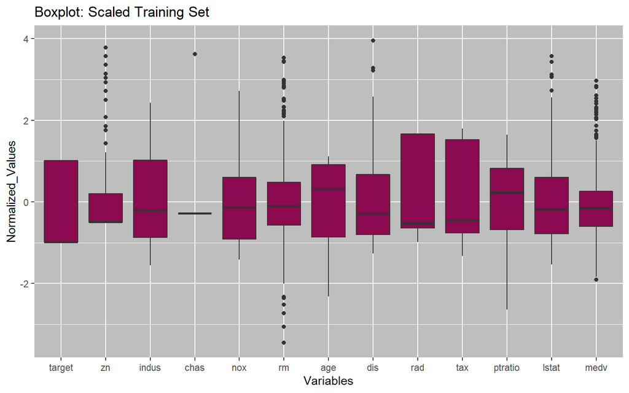

```r
data_t %>%
  scale() %>%
  as.data.frame() %>%
  stack() %>%
  ggplot(aes(x = ind, y = values)) +
  geom_boxplot(fill = 'deeppink4') +
  labs(title = 'Boxplot: Scaled Training Set',
       x = 'Variables',
       y = 'Normalized_Values')+
  theme(panel.background = element_rect(fill = 'grey'))
```

Figure 2: Boxplot: Scaled Training Set

The histogram shows that variables `zn`,`nox`, `dis`, `istat`, `medv` are right skewed; `age`, `ptratio` are left skewed; `rad`, `tax` are bimodal; `target`, `chas` are categorical however `target` is close to unbias while `chas` is highly biased; the rest are close to normal.

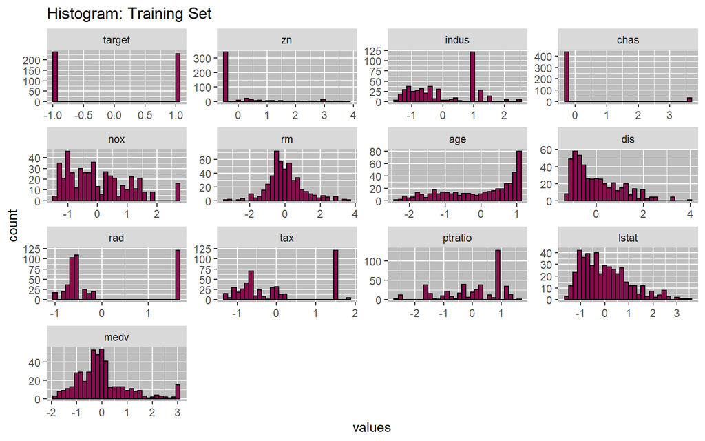

```r
data_t %>%
  scale() %>%
  as.data.frame() %>%
  stack() %>%
  ggplot(aes(x = values)) +
  geom_histogram(fill = 'deeppink4', color = 'black') +
  labs(title = 'Histogram: Training Set')+
  theme(panel.background = element_rect(fill = 'grey'))+
  facet_wrap(~ind, scale='free', ncol = 4)
```

Figure 3: Histogram: Training Set

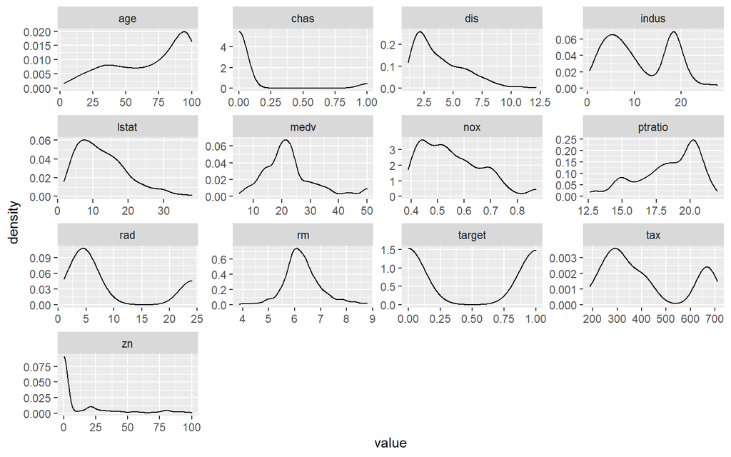

```r
data_t %>%
  select_if(is.numeric) %>%
  keep(is.numeric) %>%                     # Keep only numeric columns
  gather() %>%                             # Convert to key-value pairs
  ggplot(aes(x=value)) +                   # Plot the values
    facet_wrap(~key, scales = "free") +    # In separate panels
    geom_density()
```

The correlation matices below show that the response variable `target` has strong positive relationship (>=0.6) with variables `rad`,`tax`,`age`,`indus`,`nox`, and strong negative relationship (<=-0.6) with variable `dis`.

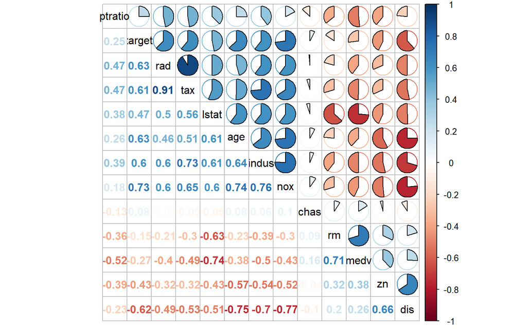

```r
data_t %>%
  cor() %>%
  #corrplot(method = "pie", type = "upper", order = 'hclust', tl.col = "black", diag = FALSE, bg= 'grey', col =     #colorRampPalette(c('deeppink4','white','steelblue1'))(100))
  corrplot.mixed(upper = 'pie', lower = 'number', order = 'hclust', tl.col = "black")
```

Figure 5: Correlation Pie Chart: Training Set

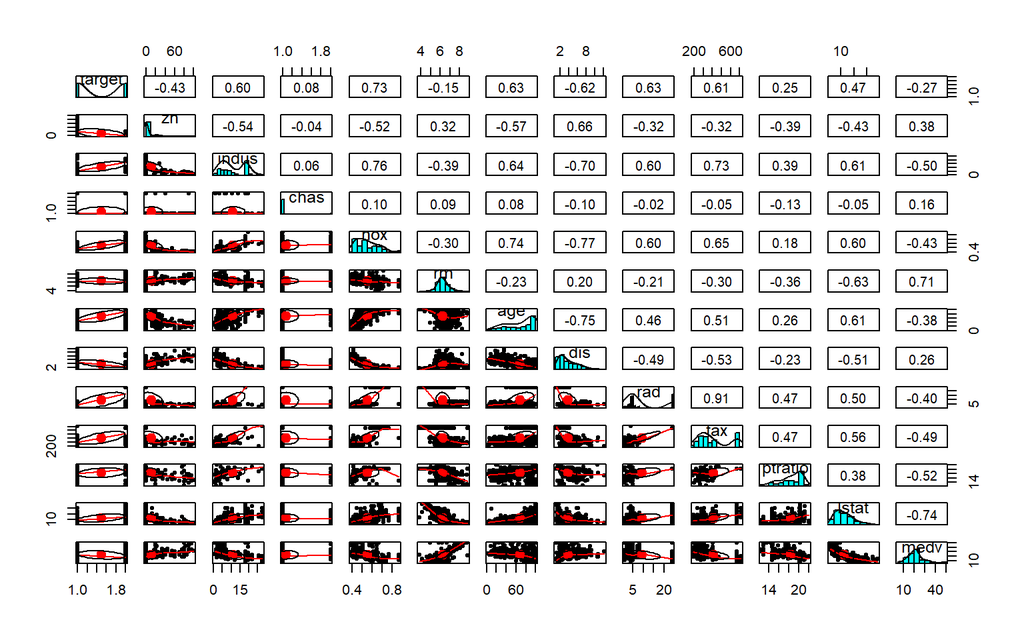

```r
pairs.panels(data_t_mod)
```

Figure 6: Correlation Matrix: Training Set

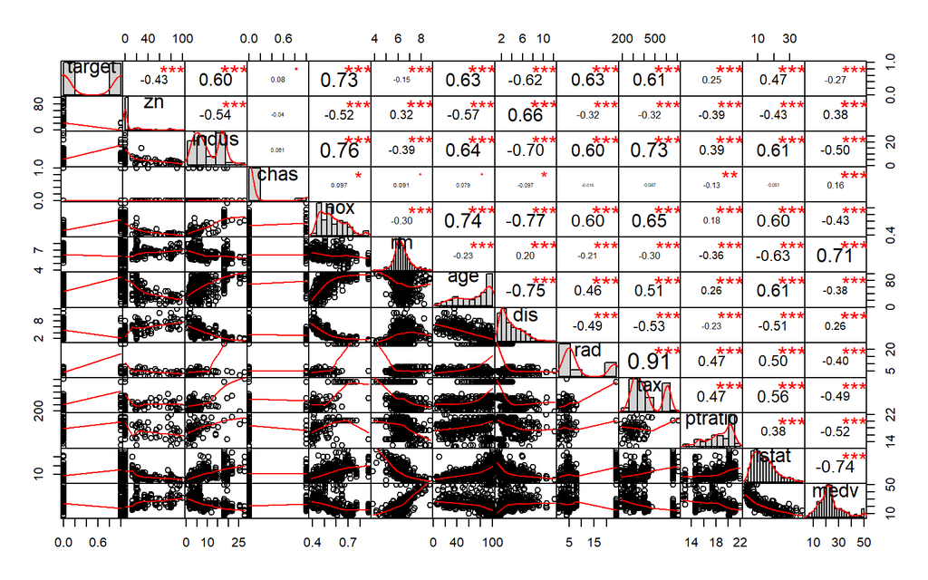

```r
PerformanceAnalytics::chart.Correlation(data_t, histogram=TRUE, pch=19)
```

Figure 7: Correlation Chart: Training Set

```r
data_t %>%
  cor() %>%
  as.data.frame() %>%
  rownames_to_column('Variable') %>%
  dplyr::rename(Correlation_vs_Response = target)
```

| Variable | Correlation_vs_Response | zn | indus | chas | nox | rm | age | dis | rad | tax | ptratio | lstat | medv |
| --- | --- | --- | --- | --- | --- | --- | --- | --- | --- | --- | --- | --- | --- |
| target | 1.00000000 | -0.43168176 | 0.60485074 | 0.08004187 | 0.72610622 | -0.15255334 | 0.63010625 | -0.61867312 | 0.62810492 | 0.61111331 | 0.2508489 | 0.46912702 | -0.2705507 |
| zn | -0.43168176 | 1.00000000 | -0.53826643 | -0.04016203 | -0.51704518 | 0.31981410 | -0.57258054 | 0.66012434 | -0.31548119 | -0.31928408 | -0.3910357 | -0.43299252 | 0.3767171 |
| indus | 0.60485074 | -0.53826643 | 1.00000000 | 0.06118317 | 0.75963008 | -0.39271181 | 0.63958182 | -0.70361886 | 0.60062839 | 0.73222922 | 0.3946898 | 0.60711023 | -0.4961743 |
| chas | 0.08004187 | -0.04016203 | 0.06118317 | 1.00000000 | 0.09745577 | 0.09050979 | 0.07888366 | -0.09657711 | -0.01590037 | -0.04676476 | -0.1286606 | -0.05142322 | 0.1615653 |
| nox | 0.72610622 | -0.51704518 | 0.75963008 | 0.09745577 | 1.00000000 | -0.29548972 | 0.73512782 | -0.76888404 | 0.59582984 | 0.65387804 | 0.1762687 | 0.59624264 | -0.4301227 |
| rm | -0.15255334 | 0.31981410 | -0.39271181 | 0.09050979 | -0.29548972 | 1.00000000 | -0.23281251 | 0.19901584 | -0.20844570 | -0.29693430 | -0.3603471 | -0.63202445 | 0.7053368 |
| age | 0.63010625 | -0.57258054 | 0.63958182 | 0.07888366 | 0.73512782 | -0.23281251 | 1.00000000 | -0.75089759 | 0.46031430 | 0.51212452 | 0.2554479 | 0.60562001 | -0.3781560 |
| dis | -0.61867312 | 0.66012434 | -0.70361886 | -0.09657711 | -0.76888404 | 0.19901584 | -0.75089759 | 1.00000000 | -0.49499193 | -0.53425464 | -0.2333394 | -0.50752800 | 0.2566948 |
| rad | 0.62810492 | -0.31548119 | 0.60062839 | -0.01590037 | 0.59582984 | -0.20844570 | 0.46031430 | -0.49499193 | 1.00000000 | 0.90646323 | 0.4714516 | 0.50310125 | -0.3976683 |
| tax | 0.61111331 | -0.31928408 | 0.73222922 | -0.04676476 | 0.65387804 | -0.29693430 | 0.51212452 | -0.53425464 | 0.90646323 | 1.00000000 | 0.4744223 | 0.56418864 | -0.4900329 |

[output cut: 3 more lines]

## Consolidated Data Dictionary

As a summary of the data exploration process, a data dictionary is created as below:

```r
data_stat <- data_t %>%
  dplyr::select(-target,-chas) %>%
  gather() %>%
  group_by(key) %>%
  summarise(Mean = mean(value),
            Median = median(value),
            Max = max(value),
            Min = min(value),
            SD = sd(value))

data_cor <- data_t %>%
  cor() %>%
  as.data.frame() %>%
  dplyr::select(target) %>%
  rownames_to_column('Variable') %>%
  dplyr::rename(Correlation_vs_Response = target)

data_t %>%
  gather() %>%
  dplyr::select(key) %>%
  unique() %>%
  dplyr::rename(Variable = key) %>%
  mutate(Description = c('whether the crime rate is above the median crime rate (1) or not (0)',
                         'proportion of residential land zoned for large lots (over 25000 square feet)',
                         'proportion of non-retail business acres per suburb',
                         'a dummy var. for whether the suburb borders the Charles River (1) or not (0)',
                         'nitrogen oxides concentration (parts per 10 million)',
                         'average number of rooms per dwelling',
                         'proportion of owner-occupied units built prior to 1940',
                         'weighted mean of distances to five Boston employment centers',
                         'index of accessibility to radial highways',
                         'full-value property-tax rate per $10,000',
                         'pupil-teacher ratio by town',
                         'lower status of the population (percent)',
                         'median value of owner-occupied homes in $1000s'),
         Var_Type_1 = case_when(Variable %in% c('target','chas') ~ 'categorical',
                                Variable %in% c('rad','tax') ~ 'discrete numerical',
                                TRUE ~ 'continuous numerical'),
         Var_Type_2 = if_else(Variable == 'target', 'response', 'predictor'),
         Missing_Value = 'No') %>%
  left_join(data_stat, by = c('Variable'='key')) %>%
  left_join(data_cor, by = 'Variable') %>%
  mutate_if(is.numeric,round,2) %>%
  kable() %>%
  kable_styling(bootstrap_options = c("striped", "hover", "condensed", "responsive"),full_width = F)
```

| Variable | Description | Var_Type_1 | Var_Type_2 | Missing_Value | Mean | Median | Max | Min | SD | Correlation_vs_Response |
| --- | --- | --- | --- | --- | --- | --- | --- | --- | --- | --- |
| target | whether the crime rate is above the median crime rate (1) or not (0) | categorical | response | No | NA | NA | NA | NA | NA | 1.00 |
| zn | proportion of residential land zoned for large lots (over 25000 square feet) | continuous numerical | predictor | No | 11.58 | 0.00 | 100.00 | 0.00 | 23.36 | -0.43 |
| indus | proportion of non-retail business acres per suburb | continuous numerical | predictor | No | 11.11 | 9.69 | 27.74 | 0.46 | 6.85 | 0.60 |
| chas | a dummy var. for whether the suburb borders the Charles River (1) or not (0) | categorical | predictor | No | NA | NA | NA | NA | NA | 0.08 |
| nox | nitrogen oxides concentration (parts per 10 million) | continuous numerical | predictor | No | 0.55 | 0.54 | 0.87 | 0.39 | 0.12 | 0.73 |
| rm | average number of rooms per dwelling | continuous numerical | predictor | No | 6.29 | 6.21 | 8.78 | 3.86 | 0.70 | -0.15 |
| age | proportion of owner-occupied units built prior to 1940 | continuous numerical | predictor | No | 68.37 | 77.15 | 100.00 | 2.90 | 28.32 | 0.63 |
| dis | weighted mean of distances to five Boston employment centers | continuous numerical | predictor | No | 3.80 | 3.19 | 12.13 | 1.13 | 2.11 | -0.62 |
| rad | index of accessibility to radial highways | discrete numerical | predictor | No | 9.53 | 5.00 | 24.00 | 1.00 | 8.69 | 0.63 |
| tax | full-value property-tax rate per $10,000 | discrete numerical | predictor | No | 409.50 | 334.50 | 711.00 | 187.00 | 167.90 | 0.61 |
| ptratio | pupil-teacher ratio by town | continuous numerical | predictor | No | 18.40 | 18.90 | 22.00 | 12.60 | 2.20 | 0.25 |
| lstat | lower status of the population (percent) | continuous numerical | predictor | No | 12.63 | 11.35 | 37.97 | 1.73 | 7.10 | 0.47 |
| medv | median value of owner-occupied homes in $1000s | continuous numerical | predictor | No | 22.59 | 21.20 | 50.00 | 5.00 | 9.24 | -0.27 |

Table 4: Data Dictionary

# Data Preparation

## Re-scale Data

```r
data_rescaled <- scale(data_t_mod[c(2,3,5:13)]) %>%
  as.data.frame() %>%
  cbind(data_t_mod[c(1,4)]) %>%
  dplyr::select(target, zn, indus, chas, everything())

DT::datatable(data_rescaled)
```

|  | target | zn | indus | chas | nox | rm | age | dis | rad | tax | ptratio | lstat | medv |
| --- | --- | --- | --- | --- | --- | --- | --- | --- | --- | --- | --- | --- | --- |
| 1 | 1 | -0.495502935416321 | 1.23797226807758 | 0 | 0.434481303529558 | 2.32435721915126 | 0.982734775035177 | -0.83048638445262 | -0.521538206872743 | -0.0387262804545447 | -1.68354995796081 | -1.25761710967871 | 2.96663146629856 |
| 2 | 1 | -0.495502935416321 | 1.23797226807758 | 1 | 2.71448132301663 | -1.25937745244706 | 1.11690903540976 | -1.17425351364536 | -0.521538206872743 | -0.0387262804545447 | -1.68354995796081 | 1.99785401046603 | -0.994544073229029 |
| 3 | 1 | -0.495502935416321 | 1.02178305320934 | 0 | 1.59162417056247 | 0.275698127390383 | 1.11690903540976 | -0.862523221703082 | 1.66590816150777 | 1.52768146870325 | 0.820040725098986 | 0.875617642492262 | -0.778086393473423 |
| 4 | 0 | 0.788487988980374 | -0.902008811530363 | 0 | -1.08266156658026 | 0.145174140934703 | -2.13858222946826 | 1.53767662510154 | -0.40640945064219 | -0.652186349516341 | -0.818673176540154 | -1.04781382382163 | 0.120212977512341 |
| 5 | 0 | -0.495502935416321 | -1.2628110822902 | 0 | -0.568375847898965 | 1.2262532461437 | 0.841498711482986 | -0.519752794113694 | -0.75179571933385 | -1.28947011058054 | -0.272435209327107 | -1.0999126263499 | 1.65706250377714 |
| 6 | 0 | -0.495502935416321 | -0.371760939927849 | 0 | -0.294090131268941 | 0.695644866421697 | 0.103540279422784 | -0.445949413484851 | -0.521538206872743 | -0.151888817465944 | 1.1386795393066 | -0.698611039307832 | 0.423253729170189 |
| 7 | 1 | -0.495502935416321 | 1.02178305320934 | 0 | 1.18876702426212 | -1.18844050328636 | 1.11690903540976 | -1.09451738537754 | 1.66590816150777 | 1.52768146870325 | 0.820040725098986 | 2.52869856595676 | -1.90366632820257 |
| 8 | 1 | -0.495502935416321 | 1.02178305320934 | 0 | 1.18876702426212 | -2.51354271360815 | 1.11690903540976 | -1.01449648522305 | 1.66590816150777 | 1.52768146870325 | 0.820040725098986 | 3.42845896637739 | -1.68720864844697 |
| 9 | 0 | -0.495502935416321 | -0.864029625134591 | 0 | -0.336947274492382 | 0.035931239227233 | -1.06871904806041 | 1.26377353210537 | -0.521538206872743 | -1.10483649756194 | 0.820040725098986 | -0.978818112365273 | -0.0421302823043636 |
| 10 | 0 | 2.92847286297487 | -1.09044400557093 | 0 | -1.39123299778903 | -0.588313913386883 | -1.73959034993332 | 2.57462598843205 | -0.982053231794957 | -0.562847504507341 | -0.909712837742329 | -0.476135071754688 | -0.182827774145508 |

[output cut: 456 more lines]

Table 5: Rescaled `training set`

# Build Models

Because we have a small number of observations to train over, we’ll use k-fold Cross Validation to train, with k = 10. We’ll hold out 15% of the data for validation while doing initial modeling, but once we select our model, we’ll retrain over the full training set.

Each of our logistic regression models will use bionomial regression with a logit link function.

## Model 1

The first model fits includes all the variables. A review of the VIF output of the model suggests some points that are highly colinear and a number of variables that may not be necessary. Model 1 uses the formula:

**target ~ .**

```r
fit1 <- glm(target ~ ., data = data_t_mod, family = "binomial")
summary(fit1)
```

```
##
## Call:
## glm(formula = target ~ ., family = "binomial", data = data_t_mod)
##
## Deviance Residuals:
##     Min       1Q   Median       3Q      Max
## -1.8464  -0.1445  -0.0017   0.0029   3.4665
##
## Coefficients:
##               Estimate Std. Error z value Pr(>|z|)
## (Intercept) -40.822934   6.632913  -6.155 7.53e-10 ***
## zn           -0.065946   0.034656  -1.903  0.05706 .
## indus        -0.064614   0.047622  -1.357  0.17485
## chas1         0.910765   0.755546   1.205  0.22803
## nox          49.122297   7.931706   6.193 5.90e-10 ***
## rm           -0.587488   0.722847  -0.813  0.41637
## age           0.034189   0.013814   2.475  0.01333 *
## dis           0.738660   0.230275   3.208  0.00134 **
## rad           0.666366   0.163152   4.084 4.42e-05 ***
## tax          -0.006171   0.002955  -2.089  0.03674 *
## ptratio       0.402566   0.126627   3.179  0.00148 **
## lstat         0.045869   0.054049   0.849  0.39608
## medv          0.180824   0.068294   2.648  0.00810 **
## ---
## Signif. codes:  0 '***' 0.001 '**' 0.01 '*' 0.05 '.' 0.1 ' ' 1
##
## (Dispersion parameter for binomial family taken to be 1)
##
##     Null deviance: 645.88  on 465  degrees of freedom
## Residual deviance: 192.05  on 453  degrees of freedom
## AIC: 218.05
##
## Number of Fisher Scoring iterations: 9
```

```r
fit2 <- glm(target ~ ., data = data_rescaled, family = "binomial")
summary(fit2)
```

```
##
## Call:
## glm(formula = target ~ ., family = "binomial", data = data_rescaled)
##
## Deviance Residuals:
##     Min       1Q   Median       3Q      Max
## -1.8464  -0.1445  -0.0017   0.0029   3.4665
##
## Coefficients:
##             Estimate Std. Error z value Pr(>|z|)
## (Intercept)   2.2645     0.7253   3.122  0.00179 **
## zn           -1.5408     0.8097  -1.903  0.05706 .
## indus        -0.4423     0.3260  -1.357  0.17485
## chas1         0.9108     0.7555   1.205  0.22803
## nox           5.7309     0.9254   6.193 5.90e-10 ***
## rm           -0.4141     0.5095  -0.813  0.41637
## age           0.9683     0.3912   2.475  0.01333 *
## dis           1.5563     0.4852   3.208  0.00134 **
## rad           5.7880     1.4171   4.084 4.42e-05 ***
## tax          -1.0362     0.4961  -2.089  0.03674 *
## ptratio       0.8844     0.2782   3.179  0.00148 **
## lstat         0.3258     0.3838   0.849  0.39608
## medv          1.6708     0.6310   2.648  0.00810 **
## ---
## Signif. codes:  0 '***' 0.001 '**' 0.01 '*' 0.05 '.' 0.1 ' ' 1
##
## (Dispersion parameter for binomial family taken to be 1)
##
##     Null deviance: 645.88  on 465  degrees of freedom
## Residual deviance: 192.05  on 453  degrees of freedom
## AIC: 218.05
##
## Number of Fisher Scoring iterations: 9
```

```r
set.seed(121)
split <- caret::createDataPartition(data_rescaled$target, p=0.85, list=FALSE)
partial_train <- data_rescaled[split, ]
validation <- data_rescaled[ -split, ]
mod1 <- caret::train(target ~., data = partial_train,
              method = "glm", family = "binomial",
              trControl = trainControl(
                  method = "cv", number = 10,
                  savePredictions = TRUE),
              tuneLength = 5,
              preProcess = c("center", "scale"))
knitr::kable(vif(mod1$finalModel))
```

|  | x |
| --- | --- |
| zn | 1.775536 |
| indus | 2.615682 |
| chas1 | 1.289891 |
| nox | 4.090926 |
| rm | 6.680172 |
| age | 2.408913 |
| dis | 3.574289 |
| rad | 2.078134 |
| tax | 2.209580 |
| ptratio | 2.433736 |
| lstat | 2.735861 |
| medv | 9.246747 |

## Model 2

Our second model ignores the colinear issues, but removes models that seemed unnecessary in Model #1. Model 2 uses the formula:

**target ~ zn + nox + age + dis + rad + ptratio + medv**

```r
# remove low p-values
mod2 <- train(target ~ zn + nox + age + dis + rad + ptratio + medv,
            data = partial_train,
            method = "glm", family = "binomial",
            trControl = trainControl(
                  method = "cv", number = 10,
                  savePredictions = TRUE),
            tuneLength = 5,
            preProcess = c("center", "scale"))
knitr::kable(vif(mod2$finalModel))
```

|  | x |
| --- | --- |
| zn | 1.801287 |
| nox | 3.049522 |
| age | 1.685178 |
| dis | 3.659469 |
| rad | 1.235992 |
| ptratio | 1.826575 |
| medv | 2.094548 |

## Model #3

**target ~ indus + rm + age + dis + tax + ptratio + lstat + medv**

```r
## Reduce Collinearity by removing high VIFs
mod3 <- train(target ~ indus + rm + age + dis + tax + ptratio + lstat + medv, data = partial_train,
              method = "glm", family = "binomial",
              trControl = trainControl(
                  method = "cv", number = 10,
                  savePredictions = TRUE),
              tuneLength = 5,
              preProcess = c("center", "scale"))
knitr::kable(vif(mod3$finalModel))
```

|  | x |
| --- | --- |
| indus | 2.190206 |
| rm | 4.462813 |
| age | 2.097140 |
| dis | 1.956005 |
| tax | 1.749705 |
| ptratio | 1.423980 |
| lstat | 2.765737 |
| medv | 5.782926 |

## Model #4

Model #4 takes the advances in model #3 and removes those values shown to be poor predictors.

**target ~ age + dis + tax + medv**

```r
## reduce collinearity, and remove low values
mod4 <- train(target ~ age + dis + tax + medv,
            data = partial_train,
            method = "glm", family = "binomial",
            trControl = trainControl(
                  method = "cv", number = 10,
                  savePredictions = TRUE),
            tuneLength = 5,
            preProcess = c("center", "scale"))
knitr::kable(vif(mod4$finalModel))
```

|  | x |
| --- | --- |
| age | 1.733106 |
| dis | 1.715677 |
| tax | 1.386751 |
| medv | 1.413739 |

# Select Models

## Fourfold Plots

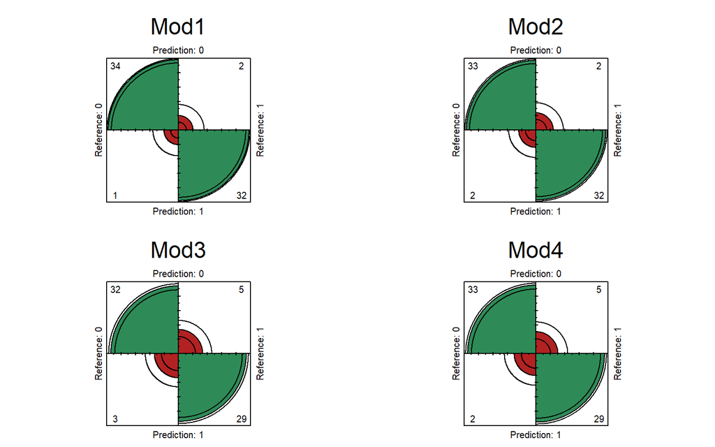

```r
preds1 <- predict(mod1, newdata = validation)
preds2 <- predict(mod2, newdata = validation)
preds3 <- predict(mod3, newdata = validation)
preds4 <- predict(mod4, newdata = validation)
m1cM <- confusionMatrix(preds1, validation$target, mode = "everything")
m2cM <- confusionMatrix(preds2, validation$target, mode = "everything")
m3cM <- confusionMatrix(preds3, validation$target, mode = "everything")
m4cM <- confusionMatrix(preds4, validation$target, mode = "everything")

par(mfrow=c(2,2))
fourfoldplot(m1cM$table, color = c("#B22222", "#2E8B57"), main="Mod1")
fourfoldplot(m2cM$table, color = c("#B22222", "#2E8B57"), main="Mod2")
fourfoldplot(m3cM$table, color = c("#B22222", "#2E8B57"), main="Mod3")
fourfoldplot(m4cM$table, color = c("#B22222", "#2E8B57"), main="Mod4")
```

## Summary Statistics

```r
eval <- data.frame(m1cM$byClass,
                   m2cM$byClass,
                   m3cM$byClass,
                   m4cM$byClass)
eval <- data.frame(t(eval))
# manipulate results DF
eval <- dplyr::select(eval, Sensitivity, Specificity, Precision, Recall, F1)
row.names(eval) <- c("Model1", "Model2", "Model3", "Model4")
knitr::kable(eval)
```

|  | Sensitivity | Specificity | Precision | Recall | F1 |
| --- | --- | --- | --- | --- | --- |
| Model1 | 0.9714286 | 0.9411765 | 0.9444444 | 0.9714286 | 0.9577465 |
| Model2 | 0.9428571 | 0.9411765 | 0.9428571 | 0.9428571 | 0.9428571 |
| Model3 | 0.9142857 | 0.8529412 | 0.8648649 | 0.9142857 | 0.8888889 |
| Model4 | 0.9428571 | 0.8529412 | 0.8684211 | 0.9428571 | 0.9041096 |

## ROC / AUC

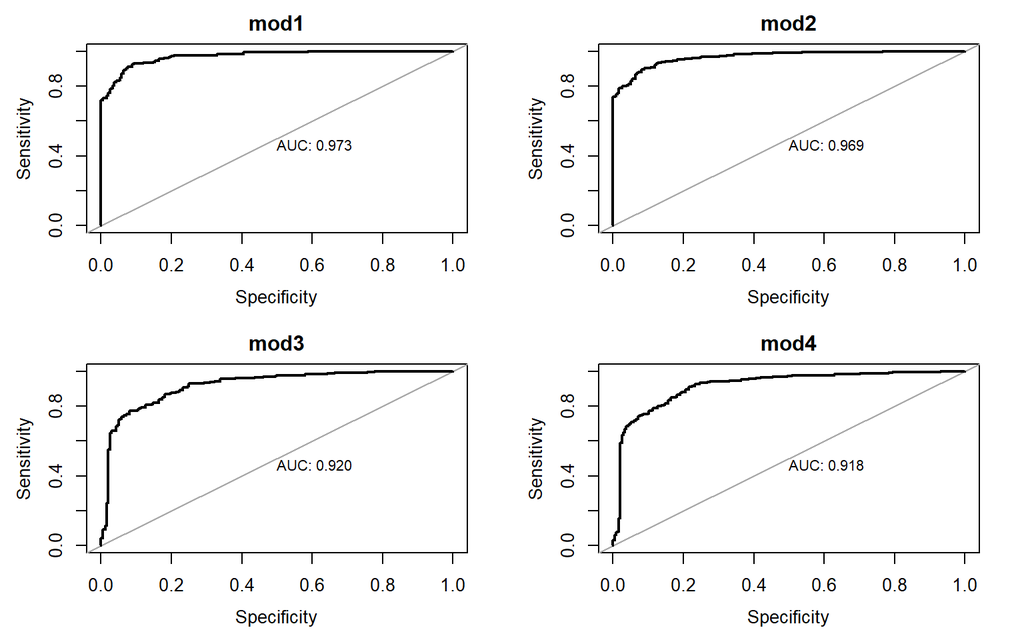

```r
getROC <- function(model) {
    name <- deparse(substitute(model))
    pred.prob1 <- predict(model, newdata = data_rescaled, type="prob")
    p1 <- data.frame(pred = data_rescaled$target, prob = pred.prob1[[1]])
    p1 <- p1[order(p1$prob),]
    rocobj <- pROC::roc(p1$pred, p1$prob)
    plot(rocobj, asp=NA, legacy.axes = TRUE, print.auc=TRUE,
         xlab="Specificity", main = name)
}
par(mfrow=c(2,2))
getROC(mod1)
getROC(mod2)
getROC(mod3)
getROC(mod4)
```

## Model Selection

Before we make predictions, let’s run this final model over our full dataset, and review some summary diagnostic plots and output.

```r
finalmod <- train(target ~ age + dis + tax + medv,
            data = data_rescaled,
            method = "glm", family = "binomial",
            trControl = trainControl(
                  method = "cv", number = 10,
                  savePredictions = TRUE),
            tuneLength = 5,
            preProcess = c("center", "scale"))
summary(finalmod)
```

```
##
## Call:
## NULL
##
## Deviance Residuals:
##     Min       1Q   Median       3Q      Max
## -2.7585  -0.4775  -0.1510   0.4092   2.7727
##
## Coefficients:
##             Estimate Std. Error z value Pr(>|z|)
## (Intercept) -0.02129    0.15913  -0.134  0.89357
## age          1.09457    0.23318   4.694 2.68e-06 ***
## dis         -0.69898    0.24751  -2.824  0.00474 **
## tax          1.31365    0.21438   6.128 8.91e-10 ***
## medv         0.38137    0.17572   2.170  0.02999 *
## ---
## Signif. codes:  0 '***' 0.001 '**' 0.01 '*' 0.05 '.' 0.1 ' ' 1
##
## (Dispersion parameter for binomial family taken to be 1)
##
##     Null deviance: 645.88  on 465  degrees of freedom
## Residual deviance: 333.92  on 461  degrees of freedom
## AIC: 343.92
##
## Number of Fisher Scoring iterations: 5
```

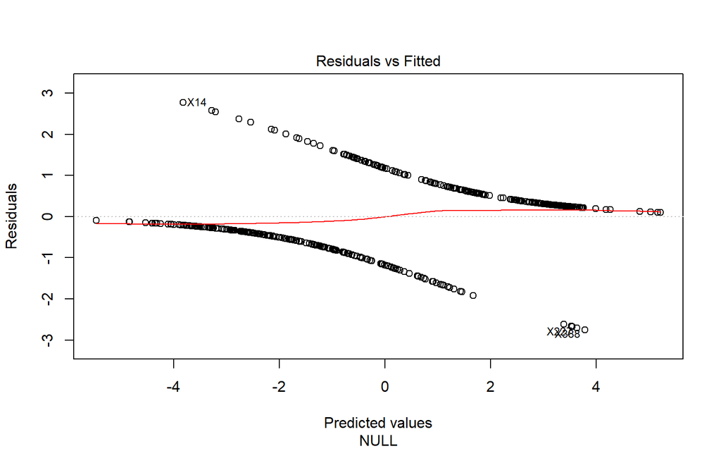

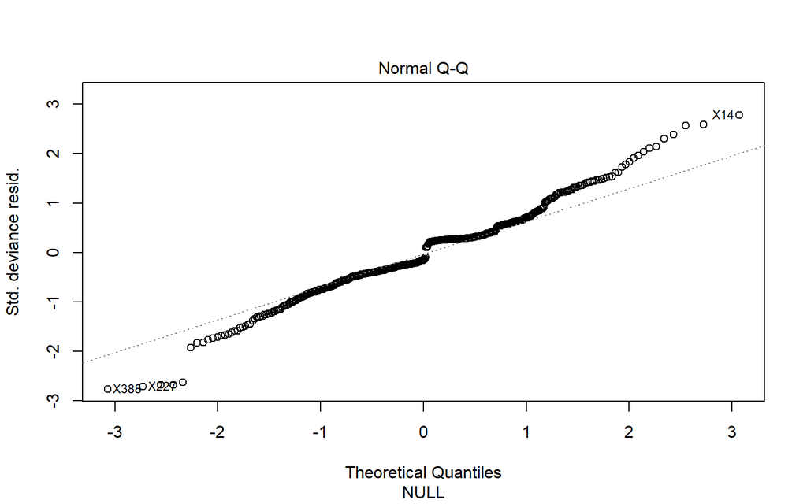

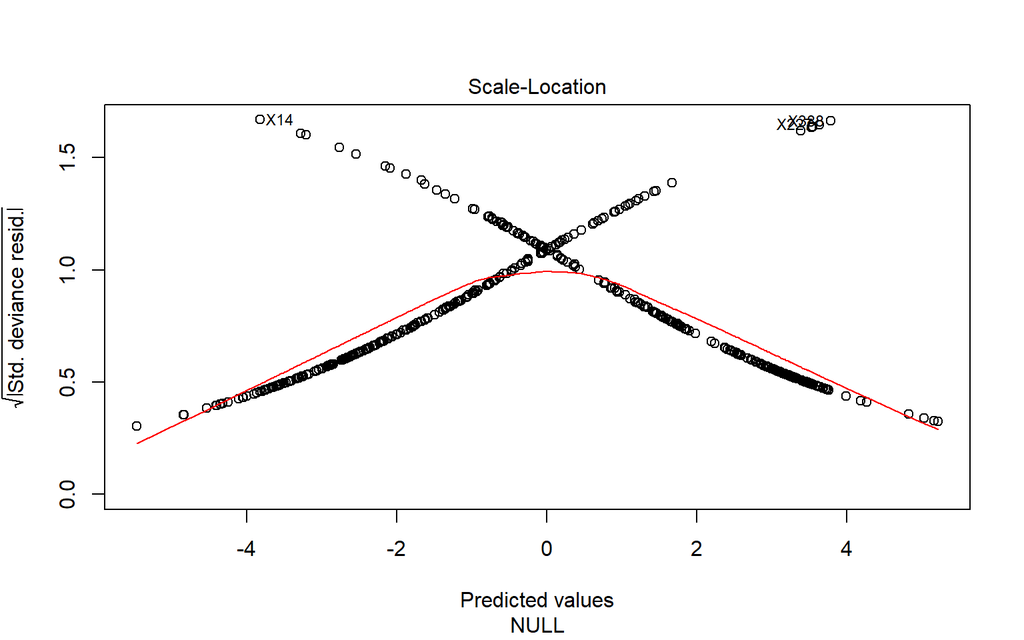

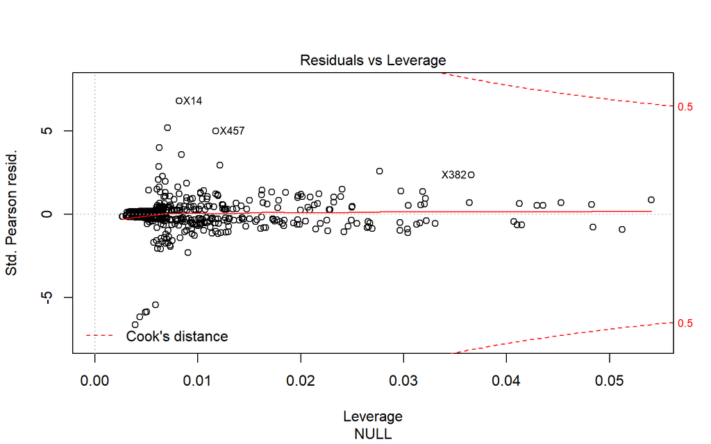

```r
plot(finalmod$finalModel)
```

## Odds Ratio

We’ll also create a table of the Odds Ratio for our final model beside the 95% confidence interval of those boundaries.

```r
odds <- round(exp(cbind(OddsRatio = coef(finalmod$finalModel), confint(finalmod$finalModel))), 3)
knitr::kable(odds)
```

|  | OddsRatio | 2.5 % | 97.5 % |
| --- | --- | --- | --- |
| (Intercept) | 0.979 | 0.717 | 1.342 |
| age | 2.988 | 1.915 | 4.790 |
| dis | 0.497 | 0.299 | 0.793 |
| tax | 3.720 | 2.493 | 5.802 |
| medv | 1.464 | 1.046 | 2.087 |

All that is left is to use our final to make predictions over the evaluation dataset.

# Make Predictions

```r
finalpreds <- predict(finalmod, data_e)
finalpreds.probs <- predict(finalmod, data_e, type="prob")
finaldf <- cbind(finalpreds.probs, prediction=finalpreds)
write.csv(finaldf, 'HW3preds.csv', row.names = FALSE)
#knitr::kable(head(finaldf))
#knitr::kable(table(finaldf$prediction))
#DT::datatable(predicted_data)
```

Critical Thinking Group 4: Rajwant Mishra, Priya Shaji, Debabrata Kabiraj, Isabel Ramesar, Sin Ying Wong and Fan Xu

3/15/2020